# (Conditional) Independence

Simulation notebook

Michael Knaus

06/23

Goals:

- Illustrate (conditional) independence in general and for causal inference with binary treatments in particular

*Acknowledgements: I thank Henri Pfleiderer for his help in preparing this notebook.*

## Formal definition of (conditional) independence

#### Discrete Variables

Independence of two discrete variables $Y$ and $W$:

$$Y \perp\!\!\!\!\perp W \iff P(Y=y, W=w)
= P(Y = y) \cdot P(W = w)$$

This implies by Bayes’ law:

$$P(Y=y \mid W=w) = \frac{P(Y=y,
W=w)}{P(W=w)} = \frac{P(Y = y) \cdot P(W = w)}{P(W=w)} = P(Y = y)$$

#### Continuous Variables

Equivalently, two continuous variables $Y$ and $W$ being independent means:

$$Y \perp\!\!\!\!\perp W \iff
f_{Y,W}(y,w) = f_Y(y) \cdot f_W(w)$$
where $f$ denotes probability density functions.

#### Mixed Case

In addition to these two cases there is a mixed case. Consider for example a continuous $Y$ and a discrete $W$. This is a very common setup in causal inference. We may think of $Y$ as a continuous outcome and $W$ a binary treatment indicator. In this case:

$$Y \perp\!\!\!\!\perp W \iff
f_{Y,W}(y,w) = f_Y(y) \cdot P(W=w)$$

Using the definition of the conditional density or probability respectively, this implies:

$$f_{Y \mid W}(y \mid w) =
\frac{f_{Y,W}(y,w)}{P(W=w)} = \frac{f_Y(y) \cdot P(W=w)}{P(W=w)}
=f_Y(y)$$
and

$$P(W = w \mid Y = y) =
\frac{f_{Y,W}(y,w)}{f_Y(y)} = \frac{f_Y(y) \cdot P(W=w)}{f_Y(y)} = P(W
=w)$$

### Conditional Independence

For compactness, we focus on the mixed case here. We have three random variables, a continuous $Y$ and binary $X$ and $W$. We say that $Y$ and $W$ are independent conditional on $X$ iff the following holds:

$$Y \perp\!\!\!\!\perp W \mid X \iff
f_{Y,W \mid X}(y, w \mid x) = f_{Y \mid X}(y \mid x) \cdot P(W = w \mid
X = x)$$

This also implies:

$$f_{Y\mid W, X}(y \mid w,x) =
\frac{f_{Y,W \mid X}(y,w \mid x)}{P(W = w \mid X = x)} = \frac{ f_{Y
\mid X}(y \mid x) \cdot P(W = w \mid X = x)}{P(W = w \mid X = x)} = f_{Y
\mid X} (y \mid x)$$
i.e., the conditioning on $W$ doesn’t matter once we condition on $X$. As the (unconditional) independence above, this works for the cases of only continuous, only discrete variables or any combination of them. Keep in mind however, the distinction between densities and probabilities.

### Conditional independence implies conditional *mean* independence

Conditional independence of $Y$ and $W$ given $X$ implies mean independence, meaning: $E[Y \mid X,W] = E[Y \mid X]$:

$$E[Y \mid W,X] = \int_{-\infty}^{+\infty} y \underbrace{f_{Y \mid
W,X}(y\mid w,x)}_{=f_{Y \mid X} (y \mid x), \ cond. \ indep.} dy =
\int_{-\infty}^{+\infty} y \ \ f_{Y \mid X} (y \mid x) \ dy = E[Y \mid
X]$$

All of this is illustrated in the following examples.

## General Example

Let’s imagine the following DGP:

$$\begin{align} Y_i= X_i + U_i \ \ \ with
\ \ \ U_i \sim \mathcal{N}(0,0.5) \\
X_i = \mathbf{1}(V_i\geq 0) \\
W_i = \mathbf{1}(Z_i\geq 0) \\
[V, Z]'\sim \mathcal{N}\left([0~~0]',\left[ \begin{array}
{rrr}
1 & \rho \\
\rho & 1
\end{array}\right]\right)
\end{align}$$

First, consider the case where $Y$ and $W$ are independent (i.e. $\rho =0$). This is illustrated by drawing a large sample from the described DGP with $\rho = 0$:

```r
library(tidyverse)
library(ggridges)
library(MASS)
set.seed(1234)
n = 1000000
mu = c(0,0)
rho = 0
sigma = matrix(c(1,rho,rho,1), nrow = 2)
draw = mvrnorm(n, mu, sigma)
X = 1*(draw[,1]>0)
W = 1*(draw[,2] > 0)
Y = X + rnorm(n, sd = 0.5)
```

Let’s plot the distributions of $Y$ for different $W=0$ and $W=1$:

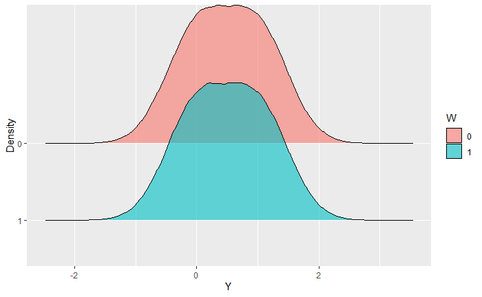

```r
tibble(Y,W,X) %>% mutate(W = as.factor(W)) %>%
  ggplot(aes(x = Y, y = fct_rev(W), fill = W))+
  geom_density_ridges(alpha = 0.6)+
  xlab("Y") + ylab("Density")
```

The distribution of $Y$ is the same when conditioning on different values of $W$. Consequently, $Y$ and $W$ are independent. This is a feature of the (conditional) distribution of $Y$ and thus also holds for the (conditional) expected value:

$$E[Y \mid W=1] = E[Y \mid W=0] = E[Y] =
0.5$$

```r
mean(Y)
```

```
[1] 0.5002274
```

```r
mean(Y[W==1])
```

```
[1] 0.49979
```

```r
mean(Y[W==0])
```

```
[1] 0.5006651
```

Now, let’s introduce some correlation between the variables $V$ and $Z$ by setting $\rho = 0.6$. This creates dependence between $Y$ and $W$:

```r
library(tidyverse)
library(MASS)
set.seed(1234)
n = 1000000
mu = c(0,0)
rho = 0.6
sigma = matrix(c(1,rho,rho,1), nrow = 2)
draw = mvrnorm(n, mu, sigma)
X =  1*(draw[,1]>0)
W = 1*(draw[,2] > 0)
Y = X + rnorm(n, sd = 0.5)
```

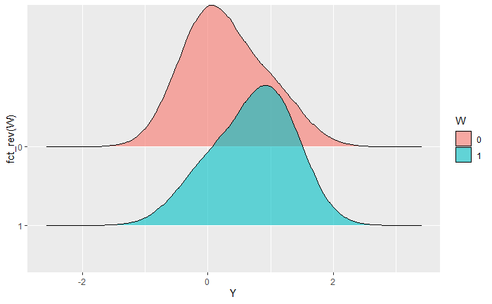

```r
tibble(Y,W,X) %>% mutate(W = as.factor(W)) %>%
  ggplot(aes(x = Y, y = fct_rev(W), fill = W))+
  geom_density_ridges(alpha = 0.6)+
  xlab("Y")
```

The distributions are not the same anymore, $Y$ is not independent of $W$.

It is however, once we condition on $X$. In the present context, this can be seen by looking at the distribution of $Y$ in the 4 different subgroups formed by the 2 binary variables $W$ and $X$.

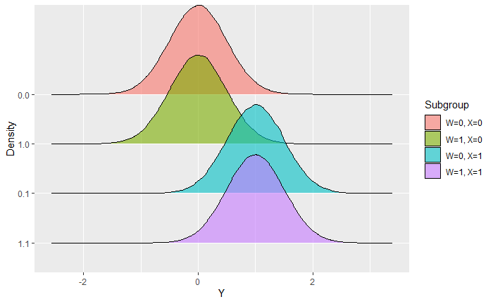

```r
tibble(Y,W,X) %>%  mutate(W = as.factor(W), X = as.factor(X), Subgroup = interaction(W,X)) %>%
  ggplot(aes(x = Y, y = fct_rev(Subgroup), fill = Subgroup))+
  geom_density_ridges(alpha = 0.6)+
  scale_fill_discrete(labels = c("W=0, X=0","W=1, X=0","W=0, X=1","W=1, X=1"))+
  xlab("Y") + ylab("Density")
```

Once we condition on $X$, i.e. look at the distribution of $Y$ in the 2 subgroups with $X=0$ and $X=1$, the distributions don’t change when conditioning on different values of $W$. $Y$ and $W$ are independent conditional on $X$: $Y \perp\!\!\!\!\perp W \mid X$

In this case, $E[Y \mid W=1] \neq E[Y \mid W=0] \neq E[Y]$:

```r
mean(Y)
```

```
[1] 0.4995484
```

```r
mean(Y[W==1])
```

```
[1] 0.7044881
```

```r
mean(Y[W==0])
```

```
[1] 0.2947923
```

Conditional on X, we can see that: $E[Y \mid W= 0, X=x] = E[Y \mid W= 1, X=x] = E[Y \mid X=x]$ for $x \in \{0,1\}$:

```r
tibble(Y,W,X) %>% group_by(X,W) %>% summarise(mean_Y = mean(Y))
```

| X | W | mean_Y |
| --- | --- | --- |
| 0 | 0 | 0.0002260437 |
| 0 | 1 | -0.0022344533 |
| 1 | 0 | 1.0003828415 |
| 1 | 1 | 0.9999189939 |

```r
tibble(Y,W,X) %>% group_by(X) %>% summarise(mean_Y = mean(Y))
```

| X | mean_Y |
| --- | --- |
| 0 | -0.0004986428 |
| 1 | 1.0000557304 |

## Example: Potential Outcomes and causal inference

Let’s look at the importance of the above concept in a causal inference context. $Y$ denotes the outcome of interest, $W$ the treatment and $X$ some additional (confounding) variable. $Y(1)$ and $Y(0)$ are the potential outcomes in the treated and untreated case respectively, so $Y = W \cdot Y(1) + (1-W) \cdot Y(0)$.

```r
library(tidyverse)
library(MASS)
set.seed(1234)
n = 1000000
mu = c(0,0)
rho = 0
sigma = matrix(c(1,rho,rho,1), nrow = 2)
draw = mvrnorm(n, mu, sigma)
X =  1*(draw[,1] > 0)
W = 1*(draw[,2] > 0)
Y0 = X + rnorm(n, sd = 0.5)
Y1 = 0.5 + X + rnorm(n, sd = 0.5)
Y = W*Y1 + (1-W)*Y0
```

$Y(0)$ and $Y(1)$ are the potential outcomes for the untreated and the treated case. $Y(0) = X + U_0$ with $U_0 \sim \mathcal{N}(0,0.5)$.

$Y(1) = 0.5 + X + U_1$ with $U_1 \sim \mathcal{N}(0,0.5)$.

In short:

$$\begin{align} Y_{i} =
\begin{cases}
X_{i} + U_{0i} & \text{if $W_{i} = 0$}\\
0.5 + X_{i} + U_{1i} & \text{if $W_{i} = 1$}
\end{cases}
\end{align}$$

and:
$$X_i = \mathbf{1}(V_i\geq 0) \\
W_i = \mathbf{1}(Z_i\geq 0) \\
[V, Z]'\sim \mathcal{N}\left([0~~0]',\left[ \begin{array}
{rrr}
1 & \rho \\
\rho & 1
\end{array}\right]\right)$$

First, consider the case with $\rho = 0$ to illustrate independence in the sense that $Y(w) \perp\!\!\!\!\perp W$.

To see that this holds in the first example, plot the distributions of $Y(1)$ for the treated and the untreated separately. As we have independence, they should look identical:

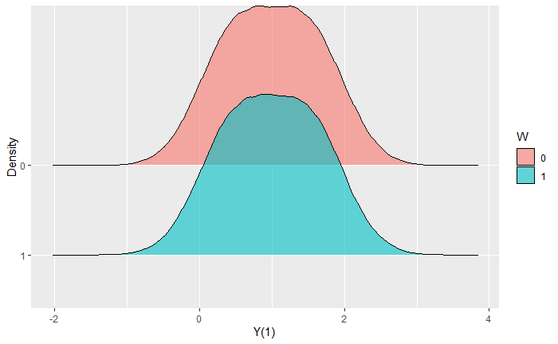

```r
tibble(Y1,Y0,Y,W,X) %>% mutate(W = as.factor(W)) %>%
  ggplot(aes(x = Y1, y = fct_rev(W), fill = W))+
  geom_density_ridges(alpha = 0.6)+
  xlab("Y(1)")+ ylab("Density")
```

Same for $Y(0)$:

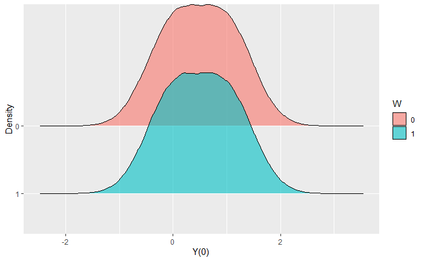

```r
tibble(Y1,Y0,Y,W,X) %>% mutate(W = as.factor(W)) %>%
  ggplot(aes(x = Y0, y = fct_rev(W), fill = W))+
  geom_density_ridges(alpha=.6)+
  xlab("Y(0)")+ ylab("Density")
```

These graphs illustrate that the potential outcomes are independent of the treatment indicator.

The individual treatment effects are given as: $Y(1) - Y(0) = 0.5 + X + U_1 - X - U_0 = 0.5 + U_1 - U_0$. The ATE is $E[Y(1)-Y(0)] = 0.5$.

As the potential outcomes are independent of $W$, we can estimate the ATE using a simple mean comparison between the treated and the untreated group:

```r
TE_mean_comparison = mean(Y[W==1]) - mean(Y[W==0])
print(TE_mean_comparison)
```

```
[1] 0.4984061
```

```r
n = 1000000
mu = c(0,0)
rho = 0.6
sigma = matrix(c(1,rho,rho,1), nrow = 2)
draw = mvrnorm(n, mu, sigma)
X =  1*(draw[,1] > 0)
W = 1*(draw[,2] > 0)
Y0 = X + rnorm(n, sd = 0.5)
Y1 = 0.5 + X + rnorm(n, sd = 0.5)
Y = W*Y1 + (1-W)*Y0
```

Intuitively, observations with a high $X$ (and thus a high $Y$) are now more likely to be treated, as $V$ and $Z$, the two variables determining $X$ and $W$, are positively correlated. Comparing means between treated and untreated will give an incorrect, too large, estimate of the ATE. In a first step, let’s again illustrate the lack of independence between the potential outcomes and $W$:

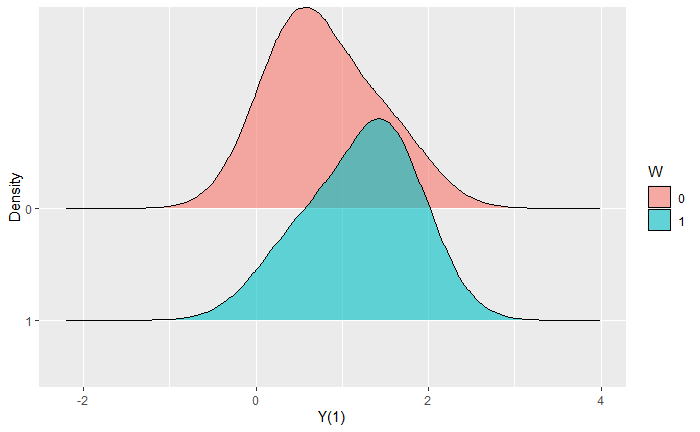

```r
tibble(Y1,Y0,Y,W,X) %>% mutate(W = as.factor(W)) %>%
  ggplot(aes(x = Y1, y = fct_rev(W), fill = W))+
  geom_density_ridges(alpha=.6)+
  xlab("Y(1)")+ylab("Density")
```

Same for $Y(0)$:

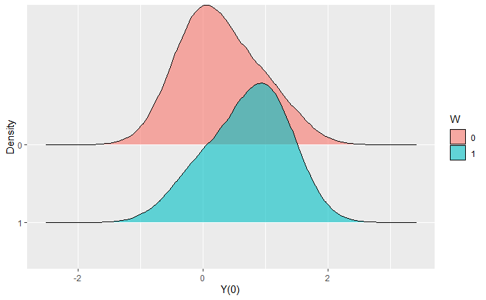

```r
tibble(Y1,Y0,Y,W,X) %>% mutate(W = as.factor(W)) %>%
  ggplot(aes(x = Y0, y = fct_rev(W), fill = W))+
  geom_density_ridges(alpha=.6)+
  xlab("Y(0)")+ylab("Density")
```

The potential outcomes are not independent of $W$. Estimate the ATE by mean comparison:

```r
TE_mean_comparison = mean(Y[W==1]) - mean(Y[W==0])
print(TE_mean_comparison)
```

```
[1] 0.9111342
```

Let’s condition on $X$ and see whether they are independent. For this purpose, look at the distributions of $Y(w)$ for the different subgroups formed by $W$ and $X$:

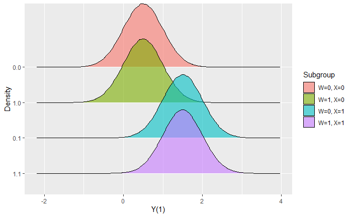

```r
tibble(Y,Y1,Y0,W,X) %>%  mutate(W = as.factor(W), X = as.factor(X), Subgroup = interaction(W,X)) %>%
  ggplot(aes(x = Y1, y = fct_rev(Subgroup), fill = Subgroup))+
  geom_density_ridges(alpha = 0.6)+
  scale_fill_discrete(labels = c("W=0, X=0","W=1, X=0","W=0, X=1","W=1, X=1"))+
  xlab("Y(1)")+ylab("Density")
```

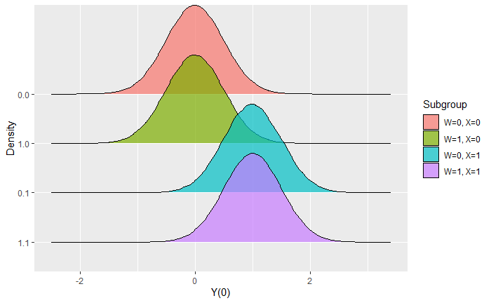

```r
tibble(Y,Y1,Y0,W,X) %>%  mutate(W = as.factor(W), X = as.factor(X), Subgroup = interaction(W,X)) %>%
  ggplot(aes(x = Y0, y = fct_rev(Subgroup), fill = Subgroup))+
  geom_density_ridges(alpha = 0.7)+
  scale_fill_discrete(labels = c("W=0, X=0","W=1, X=0","W=0, X=1","W=1, X=1"))+
  xlab("Y(0)")+ylab("Density")
```

When we look at conditional distributions of the potential outcomes, they are the same for treated and untreated. This shows that conditional on $X$, the potential outcomes are independent of $W$. What does this imply for the estimation of the ATE?

We can estimate the ATE by comparing conditional means:

```r
TE_cond_mean_comparison_1 = mean(Y[W==1 & X==1]) - mean(Y[W==0 & X==1])
print(TE_cond_mean_comparison_1)
```

```
[1] 0.5019498
```

```r
TE_cond_mean_comparison_0 = mean(Y[W==1 & X==0]) - mean(Y[W==0 & X==0])
print(TE_cond_mean_comparison_0)
```

```
[1] 0.4993736
```

```r
TE_cond_mean_comparison = mean(X)*TE_cond_mean_comparison_1 + mean(1-X)*TE_cond_mean_comparison_0
print(TE_cond_mean_comparison)
```

```
[1] 0.5006614
```

Alternatively, use a regression model with $X$ as a control variable:

```r
summary(lm(Y~ W + X))
```

```
Call:
lm(formula = Y ~ W + X)

Residuals:
     Min       1Q   Median       3Q      Max
-2.40876 -0.33723 -0.00068  0.33697  2.46799

Coefficients:
             Estimate Std. Error t value Pr(>|t|)
(Intercept) -0.001105   0.000778  -1.421    0.155
W            0.500661   0.001097 456.274   <2e-16 ***
X            1.000412   0.001097 911.718   <2e-16 ***
---
Signif. codes:  0 ‘***’ 0.001 ‘**’ 0.01 ‘*’ 0.05 ‘.’ 0.1 ‘ ’ 1

Residual standard error: 0.5003 on 999997 degrees of freedom
Multiple R-squared:  0.6241,    Adjusted R-squared:  0.6241
F-statistic: 8.301e+05 on 2 and 999997 DF,  p-value: < 2.2e-16
```

This recovers the true ATE. Note, that here the true structural model is actually linear and OLS can be used to recover the true coefficients on $X$ and $W$:

$$Y_i = W_i\cdot (0.5 + X_i + U_{1i}) +
(1-W_i) \cdot (X_{i} + U_{0i}) = 0.5W_i + X_i +W_iU_{1i} + (1-W_i)U_{0i}
= 0.5W_i + X_i + U_i$$